# M04-Reflection Essay-Advanced Data Visualization

Author

Vianey Villegas

Published

February 28, 2026

# 1 Introduction:

## 1.1 This essay will refelct what I learned from the modules on Data Visualization.

# 2 1. Summarize what you learned from the presentation by Thomas Lin Pedersen on “ggplot2 workshop: Part 2 in Step 1.

## 2.1 Response

Thomas Lin Pedersen’s presentation expanded on the **grammar of graphics framework** used in **ggplot2**. The presentation focused on how visualizations are built through layered structures.

Key concepts discussed included:

- **Layers**: multiple geoms can be added to a single plot.
- **Aesthetic mappings**: linking variables to visual properties like color or size.
- **Faceting**: splitting data into multiple panels for comparison.
- **Themes**: adjusting the appearance of plots.

**Note**

The most important idea from the workshop is that every visualization is built from a structured grammar consisting of data, aesthetics, geoms, scales, and themes.

### 2.1.1 Example Code

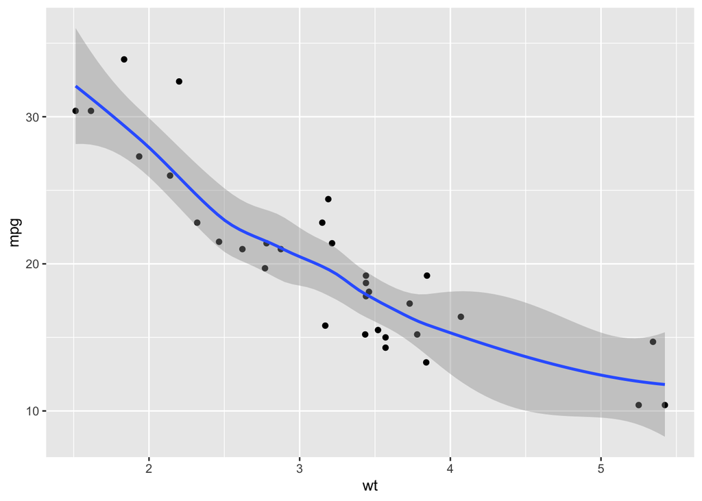

```r
library(ggplot2)

ggplot(mtcars, aes(x = wt, y = mpg)) +
  geom_point() +
  geom_smooth()
```

# 3 2. In Step 2, a short video on “ggplot2 Scales and Transformations - Data Communication / Data Visualization | Video (13:36)” was introduced. (1) Summarize it and (2) discuss how it fits with the grammar of graphics you learned in Step 1.

## 3.1 Response

The video explains how scales and transformations in ggplot2 creats charts for data to make it look more organized and cleaner.

The Concept of connect to **grammar of graphics** which is behind ggplot2. It’s a combination if components.

Components:

- Data
- Mapping
- Geoms
- Scales
- Theme

In this framework, **scales are responsible** for translating data values into visual attributes like:

- Position
- Color
- Size

Once the data is customized and mapped, the scale will then modify and determine where the values go on the plot.

Helps your data be cleaner and helps other read it better.

# 4 3. In Step 3, David Robinson’s video demonstrates impromptu data visualization. List three new functions that were not taught previously but were deemed helpful for you in the future. Briefly explain what you can do with each of the functions.

## 4.1 Response

David Robinson demonstrated **rapid** exploratory visualization using R.

3 Useful Functions:

1: reorder(): Helps **sort** bars in bar graphs

2: count(): Helps **summarize** categorical data.

3: slice_max(): Helps **identifying** top categories.

These functions help summarize data before creating the visualization.

# 5 4. What did you like about the gt and gtExtra packages demonstrated in Step 4? How do they complement data visualization using charts that we have spent so much time on so far? Under what circumstances would you prefer to use tables over charts in visualization data?

## 5.1 Response

I liked that **gt** anf **gtExtra** packages help develope aesthetic visualizations.

Features:

- Icons.
- Custom formatting
- Color gradients

Tables are better than charts when there is more data, exact numbers are requires, and there has to be a detailed comparison.

# 6 5. Pick three tips and tricks you learned from Data Visualization guru Cédric Schere in Step 5 and explain why you liked them.

## 6.1 Response

3 Tips:

- Annotate Significant Ideas I like to annotate because it makes it easier for the reader to pay attention to important factors
- Be Careful with colors Colors shouldn’t be to decorate, but to highlight important information.
- Reduce Unnecessary Details Helps it to look less messy and makes it more readable.

# 7 6. In Step 6, you will find my advanced visualization notebook. Run the codes one by one and digest as much as you can. What are you most impressed with about the visualization approach or tools demonstrated in the codebook?

## 7.1 Response

I’m more impressed by how small codes adjustments can greatly impact a visualization by improving clarity.

# 8 7. What seems to be the challenge, if any, for you when you try to master data visualization skills? How may you be able to overcome the challenge?

## 8.1 Response

What is challenging to me when doing data visualization is figuring out the errors. I feel like I try everything and I have trouble figuring out what to fix. I think I can overcome this challenge by rendering more often. That way when there is an error, it’ll be easier ti know where the error is at.